# Logistic Regression

KS

2/23/2020

# 1. Objective

The objective is to understand how logistic regression works and how to perform variable selection and test the model performance

The data used for this exercise is the Credit Card Default data. Details : http://archive.ics.uci.edu/ml/datasets/default+of+credit+card+clients

This research employed a binary variable, default payment (Yes = 1, No = 0), as the response variable.

Variables: X1: Amount of the given credit (NT dollar): it includes both the individual consumer credit and his/her family (supplementary) credit. X2: Gender (1 = male; 2 = female). X3: Education (1 = graduate school; 2 = university; 3 = high school; 4 = others). X4: Marital status (1 = married; 2 = single; 3 = others). X5: Age (year). X6 - X11: History of past payment. We tracked the past monthly payment records (from April to September, 2005) as follows: X6 = the repayment status in September, 2005; X7 = the repayment status in August, 2005; . . .;X11 = the repayment status in April, 2005. The measurement scale for the repayment status is: -1 = pay duly; 1 = payment delay for one month; 2 = payment delay for two months; . . .; 8 = payment delay for eight months; 9 = payment delay for nine months and above. X12-X17: Amount of bill statement (NT dollar). X12 = amount of bill statement in September, 2005; X13 = amount of bill statement in August, 2005; . . .; X17 = amount of bill statement in April, 2005. X18-X23: Amount of previous payment (NT dollar). X18 = amount paid in September, 2005; X19 = amount paid in August, 2005; . . .;X23 = amount paid in April, 2005.

# The first step is doing the EDA which can be referred in the ‘Exploratory Data Analysis Using R’ folder

Renaming the column having the response variable and getting the summary statistics of the data

```r
credit.data<- rename(credit.data, default=default.payment.next.month)

summary(credit.data)
```

```
##    LIMIT_BAL            SEX          EDUCATION        MARRIAGE
##  Min.   :  10000   Min.   :1.000   Min.   :1.000   Min.   :1.000
##  1st Qu.:  50000   1st Qu.:1.000   1st Qu.:1.000   1st Qu.:1.000
##  Median : 140000   Median :2.000   Median :2.000   Median :2.000
##  Mean   : 167501   Mean   :1.603   Mean   :1.844   Mean   :1.552
##  3rd Qu.: 240000   3rd Qu.:2.000   3rd Qu.:2.000   3rd Qu.:2.000
##  Max.   :1000000   Max.   :2.000   Max.   :4.000   Max.   :3.000
##       AGE           PAY_0              PAY_2            PAY_3
##  Min.   :21.0   Min.   :-2.00000   Min.   :-2.000   Min.   :-2.0000
##  1st Qu.:28.0   1st Qu.:-1.00000   1st Qu.:-1.000   1st Qu.:-1.0000
##  Median :34.0   Median : 0.00000   Median : 0.000   Median : 0.0000
##  Mean   :35.5   Mean   :-0.01575   Mean   :-0.128   Mean   :-0.1667
##  3rd Qu.:41.0   3rd Qu.: 0.00000   3rd Qu.: 0.000   3rd Qu.: 0.0000
##  Max.   :79.0   Max.   : 8.00000   Max.   : 7.000   Max.   : 7.0000
##      PAY_4             PAY_5             PAY_6           BILL_AMT1
##  Min.   :-2.0000   Min.   :-2.0000   Min.   :-2.0000   Min.   :-15308
##  1st Qu.:-1.0000   1st Qu.:-1.0000   1st Qu.:-1.0000   1st Qu.:  3690
##  Median : 0.0000   Median : 0.0000   Median : 0.0000   Median : 22658
##  Mean   :-0.2256   Mean   :-0.2678   Mean   :-0.2931   Mean   : 51392
##  3rd Qu.: 0.0000   3rd Qu.: 0.0000   3rd Qu.: 0.0000   3rd Qu.: 67207
##  Max.   : 7.0000   Max.   : 7.0000   Max.   : 8.0000   Max.   :964511
##    BILL_AMT2        BILL_AMT3         BILL_AMT4        BILL_AMT5
##  Min.   :-33350   Min.   :-157264   Min.   :-81334   Min.   :-81334
##  1st Qu.:  3156   1st Qu.:   2980   1st Qu.:  2411   1st Qu.:  1863
##  Median : 21652   Median :  20330   Median : 19078   Median : 18244
##  Mean   : 49246   Mean   :  47080   Mean   : 43102   Mean   : 40314
##  3rd Qu.: 63787   3rd Qu.:  59662   3rd Qu.: 53117   3rd Qu.: 49927
##  Max.   :983931   Max.   : 855086   Max.   :891586   Max.   :927171
##    BILL_AMT6          PAY_AMT1         PAY_AMT2            PAY_AMT3
##  Min.   :-339603   Min.   :     0   Min.   :      0.0   Min.   :     0
##  1st Qu.:   1309   1st Qu.:  1000   1st Qu.:    944.8   1st Qu.:   400
##  Median :  17130   Median :  2128   Median :   2013.0   Median :  1827
##  Mean   :  38821   Mean   :  5766   Mean   :   6250.1   Mean   :  5195
##  3rd Qu.:  48938   3rd Qu.:  5006   3rd Qu.:   5000.0   3rd Qu.:  4505
##  Max.   : 961664   Max.   :493358   Max.   :1227082.0   Max.   :896040
##     PAY_AMT4         PAY_AMT5         PAY_AMT6           default
##  Min.   :     0   Min.   :     0   Min.   :     0.0   Min.   :0.0000
##  1st Qu.:   300   1st Qu.:   300   1st Qu.:   142.8   1st Qu.:0.0000
##  Median :  1500   Median :  1518   Median :  1500.0   Median :0.0000
##  Mean   :  4878   Mean   :  4868   Mean   :  5432.7   Mean   :0.2193
##  3rd Qu.:  4078   3rd Qu.:  4121   3rd Qu.:  4061.8   3rd Qu.:0.0000
##  Max.   :432130   Max.   :426529   Max.   :528666.0   Max.   :1.0000
```

Converting the categorical variables to factors

```r
credit.data$SEX<- as.factor(credit.data$SEX)
credit.data$EDUCATION<- as.factor(credit.data$EDUCATION)
credit.data$MARRIAGE<- as.factor(credit.data$MARRIAGE)
```

As a part of EDA, it is very important to study the correlation between the response and predictor variables. At the same time, it is important to study the correlation between the predictors to avoid multicolinearity.

Also, the direction of the correlation is important to validate the model performance. For eg., if there is a negative correlation between a predictor and response variable and the coeffecients of our model is positive, something is wrong in the model.

### Keeping this in mind while performing EDA, lets get started

Splitting the data into training and testing

```r
index <- sample(nrow(credit.data),nrow(credit.data)*0.80)
credit.train = credit.data[index,]
credit.test = credit.data[-index,]
```

Fitting a logistic regression model with all the variables

```r
credit.glm0<- glm(default~., family=binomial, data=credit.train)
summary(credit.glm0)
```

```
##
## Call:
## glm(formula = default ~ ., family = binomial, data = credit.train)
##
## Deviance Residuals:
##     Min       1Q   Median       3Q      Max
## -3.1373  -0.6934  -0.5439  -0.2920   3.0393
##
## Coefficients:
##               Estimate Std. Error z value Pr(>|z|)
## (Intercept) -1.070e+00  1.545e-01  -6.925 4.36e-12 ***
## LIMIT_BAL   -1.067e-06  2.825e-07  -3.777 0.000159 ***
## SEX2        -1.912e-01  5.443e-02  -3.513 0.000444 ***
## EDUCATION2  -1.707e-01  6.284e-02  -2.716 0.006604 **
## EDUCATION3  -2.152e-01  8.496e-02  -2.533 0.011295 *
## EDUCATION4  -1.170e+00  3.211e-01  -3.643 0.000269 ***
## MARRIAGE2   -1.307e-01  6.191e-02  -2.111 0.034751 *
## MARRIAGE3   -2.938e-01  2.548e-01  -1.153 0.248858
## AGE          8.986e-03  3.340e-03   2.690 0.007141 **
## PAY_0        5.696e-01  3.172e-02  17.956  < 2e-16 ***
## PAY_2        9.102e-02  3.618e-02   2.516 0.011876 *
## PAY_3        5.656e-02  3.993e-02   1.416 0.156658
## PAY_4        5.976e-02  4.454e-02   1.342 0.179672
## PAY_5        6.515e-02  4.743e-02   1.374 0.169582
## PAY_6       -5.752e-02  4.000e-02  -1.438 0.150418
## BILL_AMT1   -4.929e-06  1.919e-06  -2.568 0.010235 *
## BILL_AMT2    3.400e-06  2.460e-06   1.382 0.166914
## BILL_AMT3    1.757e-06  2.121e-06   0.828 0.407426
## BILL_AMT4   -3.751e-06  2.383e-06  -1.574 0.115418
## BILL_AMT5    3.260e-06  2.667e-06   1.223 0.221459
## BILL_AMT6   -3.368e-07  2.070e-06  -0.163 0.870763
## PAY_AMT1    -1.138e-05  3.727e-06  -3.054 0.002257 **
## PAY_AMT2    -6.426e-06  3.178e-06  -2.022 0.043182 *
## PAY_AMT3    -1.358e-06  2.982e-06  -0.456 0.648657
## PAY_AMT4    -2.272e-06  2.777e-06  -0.818 0.413287
## PAY_AMT5    -1.608e-06  3.030e-06  -0.531 0.595688
## PAY_AMT6    -2.625e-06  2.090e-06  -1.256 0.209240
## ---
## Signif. codes:  0 '***' 0.001 '**' 0.01 '*' 0.05 '.' 0.1 ' ' 1
##
## (Dispersion parameter for binomial family taken to be 1)
##
##     Null deviance: 10045.3  on 9599  degrees of freedom
## Residual deviance:  8832.8  on 9573  degrees of freedom
## AIC: 8886.8
##
## Number of Fisher Scoring iterations: 5
```

The default link in glm() function is ‘logit’. We can specify a different link function in the function like the ‘probit’ or ‘log-log’

# Model performance

```r
glm0.deviance<-credit.glm0$deviance

glm0.AIC<-AIC(credit.glm0)

glm0.BIC<-BIC(credit.glm0)
```

Now we can use the predict function to get the predicted values. To get the probability values, we need to specify type=‘response’

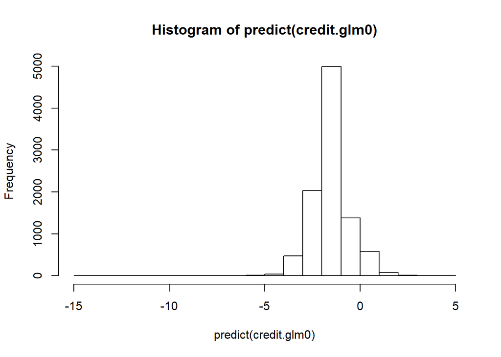

```r
hist(predict(credit.glm0))
```

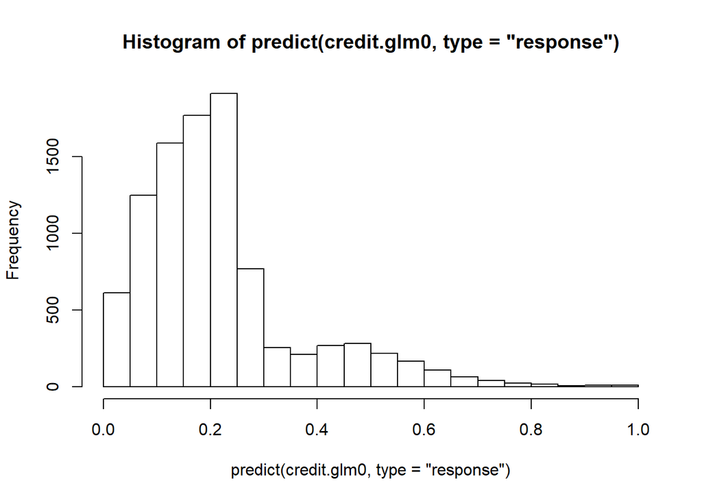

```r
hist(predict(credit.glm0,type="response"))
```

Once we have the probability values, we can specify a cut-off value to change this continous response to binary. There are several methods to select the cut-off value which we will cover in the this code, but for now lets go with the simplest one 0.5.

```r
table(predict(credit.glm0,type="response") > 0.5)
```

```
##
## FALSE  TRUE
##  8928   672
```

# In-sample predictions

By now we must be familiar with the concept of True positives and False positives. This concept is used to plot the ROC curve and guage the performance of the model.

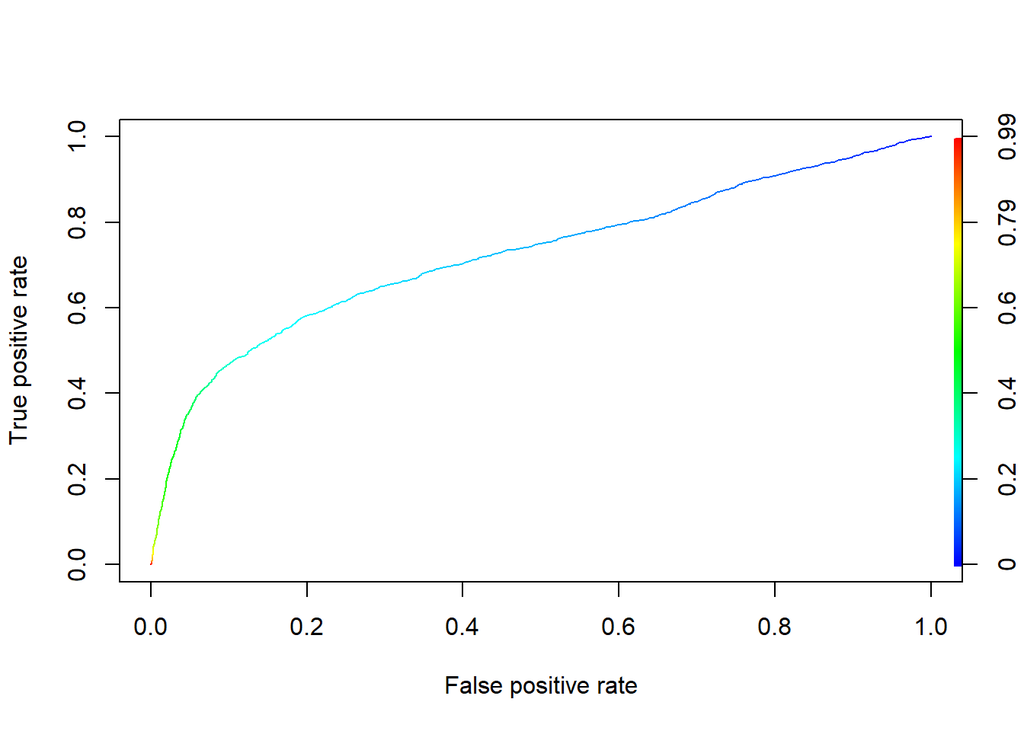

```r
pred.glm0.train<- predict(credit.glm0, type="response")
pred <- prediction(pred.glm0.train, credit.train$default)
perf <- performance(pred, "tpr", "fpr")
plot(perf, colorize=TRUE)
```

```r
# Area under the curve. Larger the better.
unlist(slot(performance(pred, "auc"), "y.values"))
```

```
## [1] 0.7251105
```

# Out of sample predictions

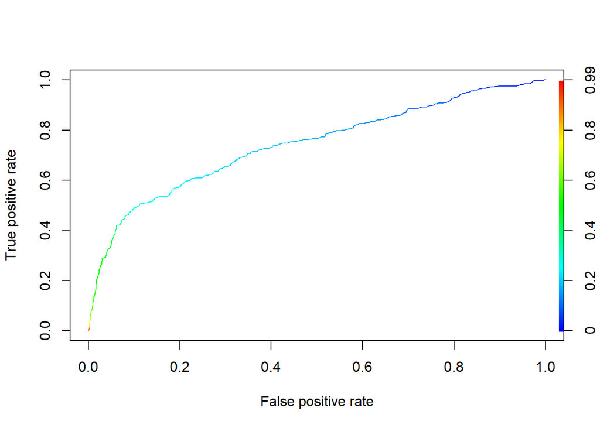

```r
pred.glm0.test<- predict(credit.glm0, newdata = credit.test, type="response")
pred <- prediction(pred.glm0.test, credit.test$default)
perf <- performance(pred, "tpr", "fpr")
plot(perf, colorize=TRUE)
```

```r
# Area under the curve. Larger the better.
unlist(slot(performance(pred, "auc"), "y.values"))
```

```
## [1] 0.7414316
```

# Selecting the cut-off values

1. Apart from selecting 0.5 another approach is to use mean of the response variable

```r
pcut1<- mean(credit.train$default)
```

Using this value, we analyze the model performance

```r
class.glm0.train<- (pred.glm0.train>pcut1)*1

table(credit.train$default, class.glm0.train, dnn = c("True", "Predicted"))
```

```
##     Predicted
## True    0    1
##    0 5251 2265
##    1  725 1359
```

To analyze the performance we can use various parameters like the misclassification rate, false positive rate, false negative rate, etc. based on the application

```r
# (equal-weighted) misclassification rate
MR<- mean(credit.train$default!=class.glm0.train)

# False positive rate
FPR<- sum(credit.train$default==0 & class.glm0.train==1)/sum(credit.train$default==0)

# False negative rate
FNR<- sum(credit.train$default==1 & class.glm0.train==0)/sum(credit.train$default==1)
```

2. Using the grid search method to find the optimal cut-off value

2.1 Defining an assymetric cost function to penalize the false negatives more than the false positives.

The inputs to this function will be a. True values b. Predicted values c. Different candidates of the cut-off value

```r
costfunc = function(obs, pred.p, pcut){
    weight1 = 5   # define the weight for "true=1 but pred=0" (FN)
    weight0 = 1    # define the weight for "true=0 but pred=1" (FP)
    c1 = (obs==1)&(pred.p<pcut)    # count for "true=1 but pred=0"   (FN)
    c0 = (obs==0)&(pred.p>=pcut)   # count for "true=0 but pred=1"   (FP)
    cost = mean(weight1*c1 + weight0*c0)  # misclassification with weight
    return(cost)
}
```

Now, we have to create a list of candidates of the cut-off values

```r
p.seq = seq(0.01, 1, 0.01)
```

Using the function defined on the training dataset, we calculate the cost for each value of the cut-off candidates

```r
cost = rep(0, length(p.seq))
for(i in 1:length(p.seq)){
    cost[i] = costfunc(obs = credit.train$default, pred.p = pred.glm0.train, pcut = p.seq[i])
}
```

We can visualize how the value of the cost function varies with the cut-off values and select the cut-off value with minimum cost

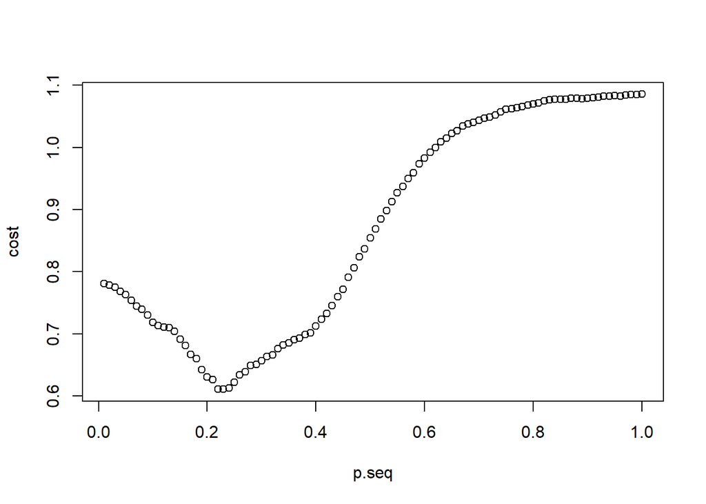

```r
plot(p.seq, cost)
```

```r
optimal.pcut.glm0 = p.seq[which(cost==min(cost))]
```

Using this value of cut-off we calculate eveluate the performance of the model

```r
class.glm0.train.opt<- (pred.glm0.train>optimal.pcut.glm0)*1

full.model.conf.met.in<-table(credit.train$default, class.glm0.train.opt,
                              dnn = c("True", "Predicted"))

MR.in<- mean(credit.train$default!= class.glm0.train.opt)

FPR.in<- sum(credit.train$default==0 &
          class.glm0.train.opt==1)/sum(credit.train$default==0)

FNR.in<- sum(credit.train$default==1 &
          class.glm0.train.opt==0)/sum(credit.train$default==1)

cost.in<- costfunc(obs = credit.train$default, pred.p = pred.glm0.train,
                pcut =optimal.pcut.glm0)
```

### We can use similar approach to eveluate the out of sample performance

```r
class.glm0.test.opt<- (pred.glm0.test>optimal.pcut.glm0)*1

MR.out<- mean(credit.test$response!= class.glm0.test.opt)

FPR.out<- sum(credit.test$response==0 &
              class.glm0.test.opt==1)/sum(credit.test$response==0)

FNR.out<- sum(credit.test$response==1 &
              class.glm0.test.opt==0)/sum(credit.test$response==1)


cost.out<- costfunc(obs = credit.test$response,pred.p = pred.glm0.test,
                pcut = optimal.pcut.glm0)
```

# Variable Selection

This is the most important step in the model building process. We need to select only the variables which affect the response variable.

There are various approaches for selecting variable: 1. Step AIC 2. Step BIC 3. LASSO Variable selection

Selecting model depends on the in-sample and out of sample performance of model selected using each of the above mentioned methods

1. Step AIC function Default: Direction = ‘backward’ We can specift the direction of search by specifying the direction. Please see ?step for details

```r
credit.glm.back.AIC <- step(credit.glm0)
```

```
## Start:  AIC=8886.8
## default ~ LIMIT_BAL + SEX + EDUCATION + MARRIAGE + AGE + PAY_0 +
##     PAY_2 + PAY_3 + PAY_4 + PAY_5 + PAY_6 + BILL_AMT1 + BILL_AMT2 +
##     BILL_AMT3 + BILL_AMT4 + BILL_AMT5 + BILL_AMT6 + PAY_AMT1 +
##     PAY_AMT2 + PAY_AMT3 + PAY_AMT4 + PAY_AMT5 + PAY_AMT6
##
##             Df Deviance    AIC
## - BILL_AMT6  1   8832.8 8884.8
## - PAY_AMT3   1   8833.0 8885.0
## - PAY_AMT5   1   8833.1 8885.1
## - BILL_AMT3  1   8833.5 8885.5
## - PAY_AMT4   1   8833.5 8885.5
## - BILL_AMT5  1   8834.3 8886.3
## - PAY_AMT6   1   8834.5 8886.5
## - PAY_4      1   8834.6 8886.6
## - PAY_5      1   8834.7 8886.7
## - BILL_AMT2  1   8834.7 8886.7
## - PAY_3      1   8834.8 8886.8
## <none>           8832.8 8886.8
## - PAY_6      1   8834.9 8886.9
## - BILL_AMT4  1   8835.3 8887.3
## - MARRIAGE   2   8838.3 8888.3
## - PAY_AMT2   1   8837.7 8889.7
## - PAY_2      1   8839.1 8891.1
## - AGE        1   8840.0 8892.0
## - BILL_AMT1  1   8840.3 8892.3
## - PAY_AMT1   1   8844.5 8896.5
## - SEX        1   8845.1 8897.1
## - LIMIT_BAL  1   8847.5 8899.5
## - EDUCATION  3   8855.9 8903.9
## - PAY_0      1   9151.9 9203.9
##
## Step:  AIC=8884.83
## default ~ LIMIT_BAL + SEX + EDUCATION + MARRIAGE + AGE + PAY_0 +
##     PAY_2 + PAY_3 + PAY_4 + PAY_5 + PAY_6 + BILL_AMT1 + BILL_AMT2 +
##     BILL_AMT3 + BILL_AMT4 + BILL_AMT5 + PAY_AMT1 + PAY_AMT2 +
##     PAY_AMT3 + PAY_AMT4 + PAY_AMT5 + PAY_AMT6
##
##             Df Deviance    AIC
## - PAY_AMT3   1   8833.0 8883.0
```

[output cut: 254 more lines]

```
##
##             Df Deviance    AIC
## <none>           8843.8 8875.8
## - MARRIAGE   2   8849.5 8877.5
## - BILL_AMT2  1   8849.2 8879.2
## - AGE        1   8851.0 8881.0
## - PAY_AMT2   1   8851.1 8881.1
## - BILL_AMT1  1   8852.9 8882.9
## - PAY_2      1   8855.8 8885.8
## - SEX        1   8855.9 8885.9
## - PAY_4      1   8856.7 8886.7
## - PAY_AMT1   1   8858.0 8888.0
## - LIMIT_BAL  1   8862.3 8892.3
## - EDUCATION  3   8866.9 8892.9
## - PAY_0      1   9168.8 9198.8
```

```r
summary(credit.glm.back.AIC)
```

```
##
## Call:
## glm(formula = default ~ LIMIT_BAL + SEX + EDUCATION + MARRIAGE +
##     AGE + PAY_0 + PAY_2 + PAY_4 + BILL_AMT1 + BILL_AMT2 + PAY_AMT1 +
##     PAY_AMT2, family = binomial, data = credit.train)
##
## Deviance Residuals:
##     Min       1Q   Median       3Q      Max
## -3.1183  -0.6925  -0.5447  -0.2947   2.9970
##
## Coefficients:
##               Estimate Std. Error z value Pr(>|z|)
## (Intercept) -1.071e+00  1.542e-01  -6.946 3.76e-12 ***
## LIMIT_BAL   -1.155e-06  2.730e-07  -4.231 2.33e-05 ***
## SEX2        -1.894e-01  5.434e-02  -3.485 0.000492 ***
## EDUCATION2  -1.669e-01  6.274e-02  -2.660 0.007820 **
## EDUCATION3  -2.119e-01  8.481e-02  -2.499 0.012462 *
## EDUCATION4  -1.177e+00  3.208e-01  -3.669 0.000244 ***
## MARRIAGE2   -1.325e-01  6.178e-02  -2.145 0.031949 *
## MARRIAGE3   -3.021e-01  2.549e-01  -1.185 0.236017
## AGE          8.957e-03  3.336e-03   2.685 0.007261 **
## PAY_0        5.734e-01  3.163e-02  18.127  < 2e-16 ***
## PAY_2        1.104e-01  3.178e-02   3.472 0.000516 ***
## PAY_4        1.046e-01  2.921e-02   3.581 0.000342 ***
## BILL_AMT1   -5.372e-06  1.904e-06  -2.822 0.004766 **
## BILL_AMT2    4.428e-06  1.985e-06   2.230 0.025744 *
## PAY_AMT1    -1.215e-05  3.636e-06  -3.342 0.000831 ***
## PAY_AMT2    -6.829e-06  2.877e-06  -2.373 0.017622 *
## ---
## Signif. codes:  0 '***' 0.001 '**' 0.01 '*' 0.05 '.' 0.1 ' ' 1
##
## (Dispersion parameter for binomial family taken to be 1)
##
##     Null deviance: 10045.3  on 9599  degrees of freedom
## Residual deviance:  8843.8  on 9584  degrees of freedom
## AIC: 8875.8
##
## Number of Fisher Scoring iterations: 5
```

```r
credit.glm.back.AIC.deviance<-credit.glm.back.AIC$deviance

credit.glm.back.AIC.AIC<-AIC(credit.glm.back.AIC)

credit.glm.back.AIC.BIC<-BIC(credit.glm.back.AIC)
```

2. Step BIC

```r
credit.glm.back.BIC <- step(credit.glm0, k=log(nrow(credit.train)))
```

```
## Start:  AIC=9080.38
## default ~ LIMIT_BAL + SEX + EDUCATION + MARRIAGE + AGE + PAY_0 +
##     PAY_2 + PAY_3 + PAY_4 + PAY_5 + PAY_6 + BILL_AMT1 + BILL_AMT2 +
##     BILL_AMT3 + BILL_AMT4 + BILL_AMT5 + BILL_AMT6 + PAY_AMT1 +
##     PAY_AMT2 + PAY_AMT3 + PAY_AMT4 + PAY_AMT5 + PAY_AMT6
##
##             Df Deviance    AIC
## - MARRIAGE   2   8838.3 9067.5
## - BILL_AMT6  1   8832.8 9071.2
## - PAY_AMT3   1   8833.0 9071.4
## - PAY_AMT5   1   8833.1 9071.5
## - BILL_AMT3  1   8833.5 9071.9
## - PAY_AMT4   1   8833.5 9071.9
## - BILL_AMT5  1   8834.3 9072.7
## - PAY_AMT6   1   8834.5 9072.9
## - PAY_4      1   8834.6 9073.0
## - PAY_5      1   8834.7 9073.1
## - BILL_AMT2  1   8834.7 9073.1
## - PAY_3      1   8834.8 9073.2
## - PAY_6      1   8834.9 9073.3
## - BILL_AMT4  1   8835.3 9073.7
## - EDUCATION  3   8855.9 9075.9
## - PAY_AMT2   1   8837.7 9076.1
## - PAY_2      1   8839.1 9077.5
## - AGE        1   8840.0 9078.4
## - BILL_AMT1  1   8840.3 9078.7
## <none>           8832.8 9080.4
## - PAY_AMT1   1   8844.5 9082.9
## - SEX        1   8845.1 9083.5
## - LIMIT_BAL  1   8847.5 9085.9
## - PAY_0      1   9151.9 9390.3
##
## Step:  AIC=9067.53
## default ~ LIMIT_BAL + SEX + EDUCATION + AGE + PAY_0 + PAY_2 +
##     PAY_3 + PAY_4 + PAY_5 + PAY_6 + BILL_AMT1 + BILL_AMT2 + BILL_AMT3 +
##     BILL_AMT4 + BILL_AMT5 + BILL_AMT6 + PAY_AMT1 + PAY_AMT2 +
##     PAY_AMT3 + PAY_AMT4 + PAY_AMT5 + PAY_AMT6
##
##             Df Deviance    AIC
## - BILL_AMT6  1   8838.3 9058.4
```

[output cut: 305 more lines]

```
## Step:  AIC=8968.7
## default ~ LIMIT_BAL + SEX + AGE + PAY_0 + PAY_2 + PAY_4 + BILL_AMT1 +
##     PAY_AMT1 + PAY_AMT2
##
##             Df Deviance    AIC
## <none>           8877.0 8968.7
## - PAY_AMT2   1   8886.5 8969.1
## - PAY_AMT1   1   8886.6 8969.2
## - BILL_AMT1  1   8888.1 8970.6
## - PAY_2      1   8888.8 8971.3
## - LIMIT_BAL  1   8888.9 8971.5
## - SEX        1   8889.3 8971.8
## - AGE        1   8889.6 8972.1
## - PAY_4      1   8891.5 8974.0
## - PAY_0      1   9205.1 9287.6
```

```r
summary(credit.glm.back.BIC)
```

```
##
## Call:
## glm(formula = default ~ LIMIT_BAL + SEX + AGE + PAY_0 + PAY_2 +
##     PAY_4 + BILL_AMT1 + PAY_AMT1 + PAY_AMT2, family = binomial,
##     data = credit.train)
##
## Deviance Residuals:
##     Min       1Q   Median       3Q      Max
## -3.1165  -0.6885  -0.5512  -0.3018   2.8940
##
## Coefficients:
##               Estimate Std. Error z value Pr(>|z|)
## (Intercept) -1.345e+00  1.138e-01 -11.826  < 2e-16 ***
## LIMIT_BAL   -8.888e-07  2.606e-07  -3.411 0.000648 ***
## SEX2        -1.894e-01  5.388e-02  -3.515 0.000440 ***
## AGE          1.008e-02  2.833e-03   3.558 0.000373 ***
## PAY_0        5.772e-01  3.165e-02  18.235  < 2e-16 ***
## PAY_2        1.094e-01  3.178e-02   3.444 0.000574 ***
## PAY_4        1.101e-01  2.902e-02   3.794 0.000148 ***
## BILL_AMT1   -1.472e-06  4.487e-07  -3.280 0.001037 **
## PAY_AMT1    -8.656e-06  3.166e-06  -2.735 0.006247 **
## PAY_AMT2    -7.509e-06  2.825e-06  -2.658 0.007871 **
## ---
## Signif. codes:  0 '***' 0.001 '**' 0.01 '*' 0.05 '.' 0.1 ' ' 1
##
## (Dispersion parameter for binomial family taken to be 1)
##
##     Null deviance: 10045  on 9599  degrees of freedom
## Residual deviance:  8877  on 9590  degrees of freedom
## AIC: 8897
##
## Number of Fisher Scoring iterations: 5
```

```r
credit.glm.back.BIC.deviance<-credit.glm.back.BIC$deviance

credit.glm.back.BIC.AIC<-AIC(credit.glm.back.BIC)

credit.glm.back.BIC.BIC<-BIC(credit.glm.back.BIC)
```

3. LASSO Variable selection

Data preperation

```r
dummy<- model.matrix(~ ., data = credit.data)

credit.data.lasso<- data.frame(dummy[,-1])

credit.train.X = as.matrix(select(credit.data.lasso, -default)[index,])
credit.test.X = as.matrix(select(credit.data.lasso, -default)[-index,])
credit.train.Y = credit.data.lasso[index, "default"]
credit.test.Y = credit.data.lasso[-index, "default"]
```

Fitting a LASSO model with all the variables

```r
credit.lasso<- glmnet(x=credit.train.X, y=credit.train.Y, family = "binomial")
```

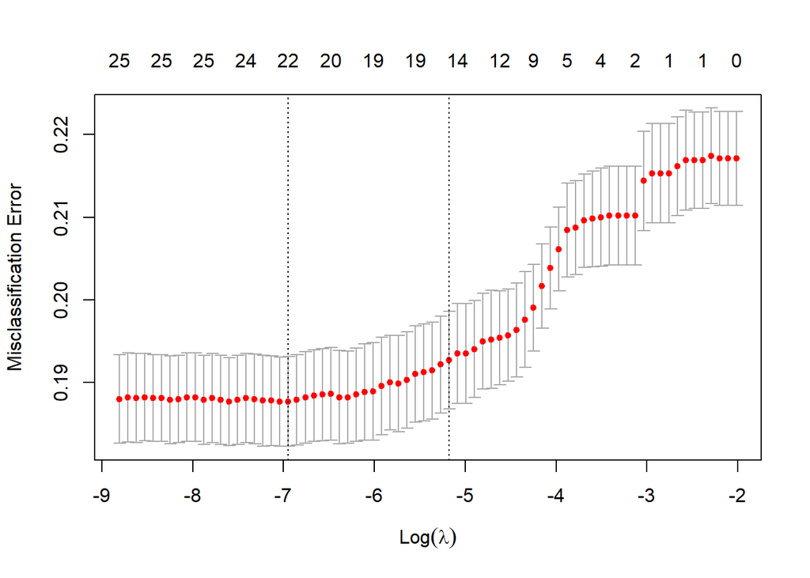

```r
credit.lasso.cv<- cv.glmnet(x=credit.train.X, y=credit.train.Y, family = "binomial", type.measure = "class")
plot(credit.lasso.cv)
```

Refit the model on the entire training dataset

```r
credit.lasso<-glmnet(x=credit.train.X, y=credit.train.Y, family = "binomial",
                     lambda =credit.lasso.cv$lambda.min)
```

Extracting the coeffecients and variables selected

```r
coef(credit.lasso, s=credit.lasso.cv$lambda.min)
```

```
## 27 x 1 sparse Matrix of class "dgCMatrix"
##                         1
## (Intercept) -1.109334e+00
## LIMIT_BAL   -1.011280e-06
## SEX2        -1.779674e-01
## EDUCATION2  -1.332956e-01
## EDUCATION3  -1.668736e-01
## EDUCATION4  -1.039887e+00
## MARRIAGE2   -1.135624e-01
## MARRIAGE3   -2.256229e-01
## AGE          8.264781e-03
## PAY_0        5.705816e-01
## PAY_2        8.522466e-02
## PAY_3        5.952547e-02
## PAY_4        5.554884e-02
## PAY_5        4.194860e-02
## PAY_6       -2.133383e-02
## BILL_AMT1   -1.313693e-06
## BILL_AMT2    .
## BILL_AMT3    .
## BILL_AMT4    .
## BILL_AMT5    2.760239e-07
## BILL_AMT6    .
## PAY_AMT1    -7.542009e-06
## PAY_AMT2    -5.048276e-06
## PAY_AMT3    -2.456448e-06
## PAY_AMT4    -1.851920e-07
## PAY_AMT5    -1.587227e-06
## PAY_AMT6    -2.232645e-06
```

# In-sample performance of the model selected using LASSO

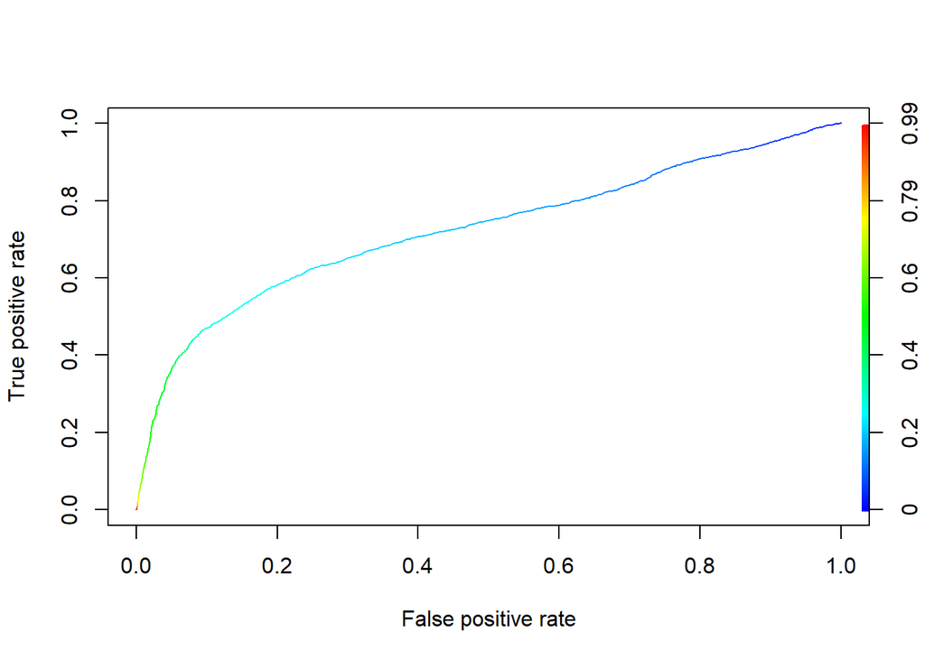

```r
pred.lasso.train<- predict(credit.lasso.cv, newx=credit.train.X,
                           s=credit.lasso.cv$lambda.min, type = "response")


pred <- prediction(pred.lasso.train, credit.train.Y)

perf <- performance(pred, "tpr", "fpr")#

plot(perf, colorize=TRUE)#Color shows cutoff
```

```r
AUC.lasso.insample<-unlist(slot(performance(pred, "auc"), "y.values"))
```

# Out of sample prediction

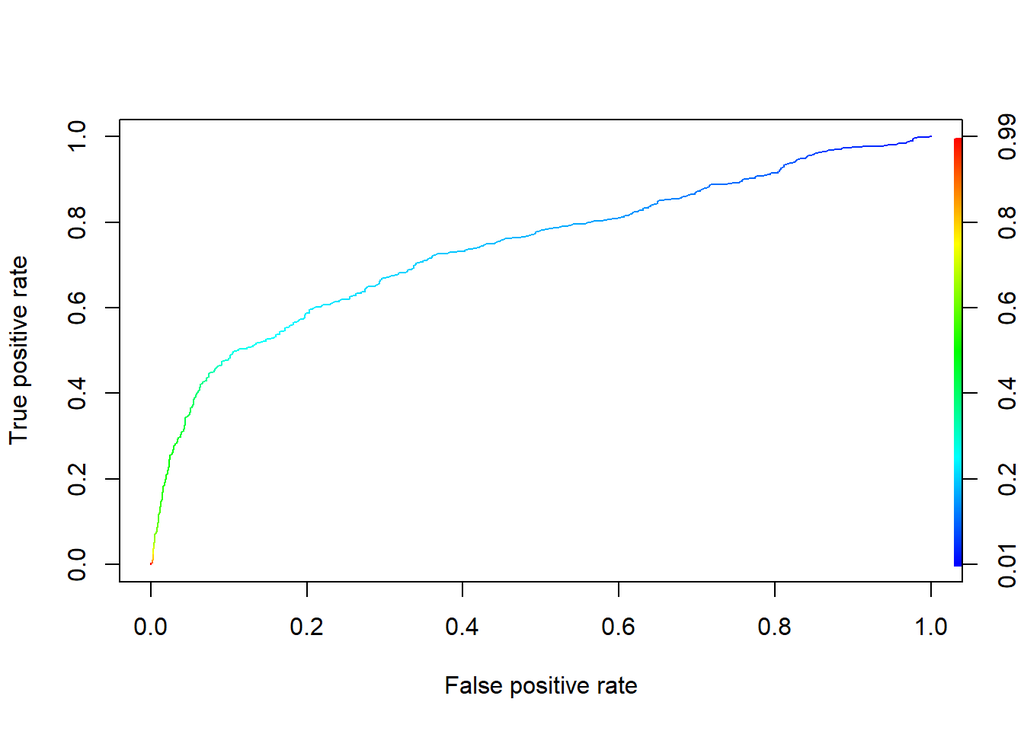

```r
pred.lasso.test<- predict(credit.lasso.cv, newx=credit.test.X,
                          s=credit.lasso.cv$lambda.min, type = "response")


pred <- prediction(pred.lasso.test, credit.test.Y)
perf <- performance(pred, "tpr", "fpr")
plot(perf, colorize=TRUE)
```

```r
AUC.lasso.outsample<-unlist(slot(performance(pred, "auc"), "y.values"))
```

### Remember the cost function we defined earlier? We can use that cost function to calculate the assymetric cost

Optimal cut-off by grid search method with asymmetric cost

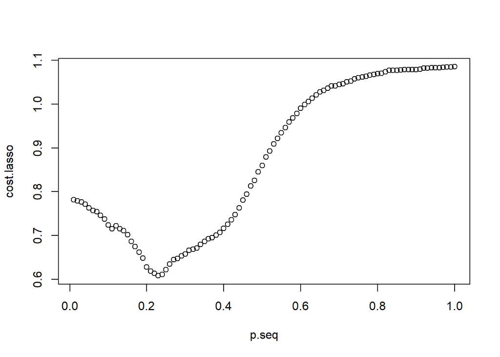

```r
cost.lasso = rep(0, length(p.seq))
for(i in 1:length(p.seq)){
  cost.lasso[i] = costfunc(obs = credit.train.Y, pred.p = pred.lasso.train, pcut = p.seq[i])
}

# Plot of the cut-off values and cost
plot(p.seq, cost.lasso)
```

```r
# The optimal pcut
optimal.pcut.lasso = p.seq[which(cost.lasso==min(cost.lasso))]
```

Using optimal cutoff to eveluate in-sample model performance

```r
class.lasso.train.opt<-(pred.lasso.train>optimal.pcut.lasso)*1

lasso.conf.met<-table(credit.train.Y, class.lasso.train.opt,
                      dnn = c("True", "Predicted"))

MR.lasso<- mean(credit.train.Y!= class.lasso.train.opt)

FPR.lasso<- sum(credit.train.Y==0 &
                class.lasso.train.opt==1)/sum(credit.train.Y==0)

FNR.lasso<- sum(credit.train.Y==1 &
                class.lasso.train.opt==0)/sum(credit.train.Y==1)


cost.lasso<- costfunc(obs = credit.train.Y,pred.p = pred.lasso.train,
                pcut = optimal.pcut.lasso)
```

Using optimal cutoff to eveluate out of sample model performance

```r
class.lasso.test.opt<-(pred.lasso.test>optimal.pcut.lasso)*1

lasso.conf.met.out<-table(credit.test.Y, class.lasso.test.opt,
                          dnn = c("True", "Predicted"))


MR.lasso.out<- mean(credit.test.Y!= class.lasso.test.opt)

FPR.lasso.out<- sum(credit.test.Y==0 &
                    class.lasso.test.opt==1)/sum(credit.test.Y==0)

FNR.lasso.out<- sum(credit.test.Y==1 &
                    class.lasso.test.opt==0)/sum(credit.test.Y==1)


cost.lasso.out<- costfunc(obs = credit.test.Y,pred.p = pred.lasso.test,
                pcut = optimal.pcut.lasso)
```

# Next Steps:

1. Eveluate the performance of the models selected using stepAIC and stepBIC functions
2. Compare the default model with the other models built
3. Select the model with best performance
4. We can use the cut-off value selected in LASSO to calculate the AUC with assymetric cost
5. We can also define an assymetric cost function for cv.glm to get the shrinkage parameters with assymetric costs